# Exploring the BRFSS data

## Setup

### Load packages

```r
library(ggplot2)
library(dplyr)
```

### Load data

```r
load("brfss2013.RData")
```

## Part 1: Data

In 1984, the Centers for Disease Control and Prevention (CDC) initiated the state-based Behavioral Risk Factor Surveillance System (BRFSS)–a cross-sectional telephone survey that state health departments conduct monthly over landline telephones and cellular telephones with a standardized questionnaire and technical and methodologic assistance from CDC. Today, all 50 states, the District of Columbia, Puerto Rico, and Guam collect data annually and American Samoa, Federated States of Micronesia, and Palau collect survey data over a limited point-in-time via telephone interviews. In order to respond to the rapid rise in the proportion of U.S. households that contain only cellular telephones, BRFSS surveys have had to add cellular telephones to their samples. At the same time, new methods of weighting to adjust survey data for differences between the demographic characteristics of respondents and the target population have been adopted.

This is a clear example of a *observational study* that contains both prospectively- and retrospectively-collected variables, as you can see from the variables description in the *brfss_codebook.html* file.

States (or who conducts data collection for them) conduct interviews following a suggested BRFSS protocol. In order to conduct the BRFSS, states refer CDC to make sure data collection procedures are in place to follow the methodology. This is an example of *stratified sampling*, where the strata are the states (geographic stratification). For each state, the BRFSS uses two samples: one for landline telephone respondents and one for cellular telephone respondents:

- *Landline sample*
- Disproportionate stratified sampling (DSS) has been used for the landline sample since 2003. DDS draws telephone numbers from two strata (lists) that are based on the presumed density of known telephone household numbers.
- *Cellular sample*
- The sample is randomly generated from a sampling frame of confirmed cellular area code and prefix combinations.

The interviews will determine eligible households and eligible household members (aged 18 years or older). For more details about the data collection, click the following link: https://www.cdc.gov/brfss/data_documentation/pdf/userguidejune2013.pdf.

Since this data is collected in a random framework from the U.S. residents population (only adults, members of an eligible household): + we can consider the sampe as a good generalization of the selected population + we can safetely apply the usual statistical methods.

This is not a randomized experiment, so the evidence of a naturally occurring association between variables **cannot** be confused with causal connections.

## Part 2: Research questions

**Research quesion 1:**

Do individuals with any diseases consider themself not having poor health?

**Research quesion 2:**

Do individuals that declare to be nervous, hopeless, restless, etc. not recognize these deseases as mental deseases and so they declare to not have poor mental healt?

**Research quesion 3:**

In common sense doing exercises is one of the most effective ways to improve your mental health. So the question we want to answer is the following: “May physical activity be correlated with mental healt? If yes, do more exercises a week doing healthier?”

## Part 3: Exploratory data analysis

**Research quesion 1:**

*“Do individuals with any diseases consider themself not having poor health?”*

Let’s analyze the *poorhlth*, *menthhlth*, *physhlth* variables

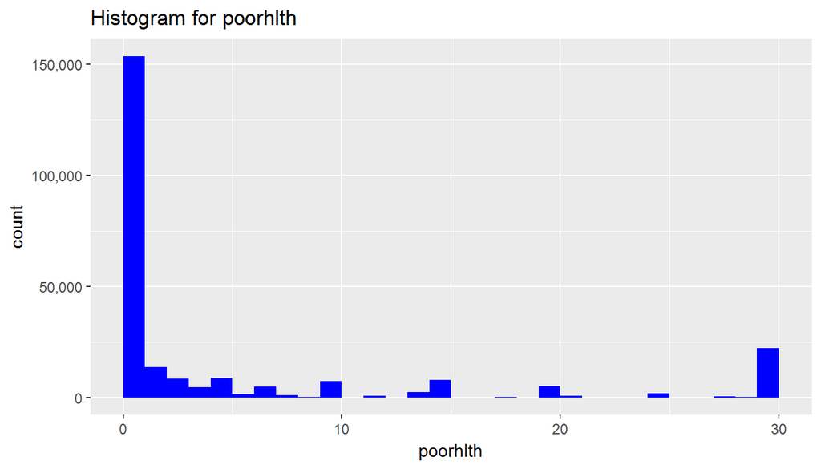

```r
# Used to avoid scientific notation on the axis
require(scales)

brfss2013 %>%
  ggplot(aes(poorhlth)) +
    geom_histogram(breaks=seq(0, 30, by = 1),
                   fill="blue") +
    scale_y_continuous(labels = comma) +
    labs(title="Histogram for poorhlth")
```

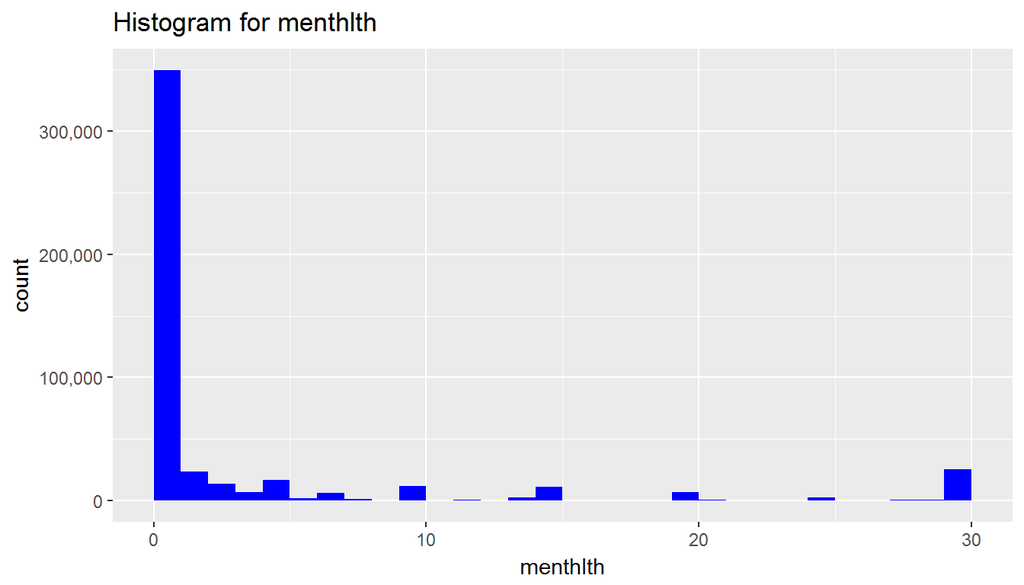

```r
brfss2013 %>%
  ggplot(aes(menthlth)) +
    geom_histogram(breaks=seq(0, 30, by = 1),
                   fill="blue") +
    scale_y_continuous(labels = comma) +
    labs(title="Histogram for menthlth")
```

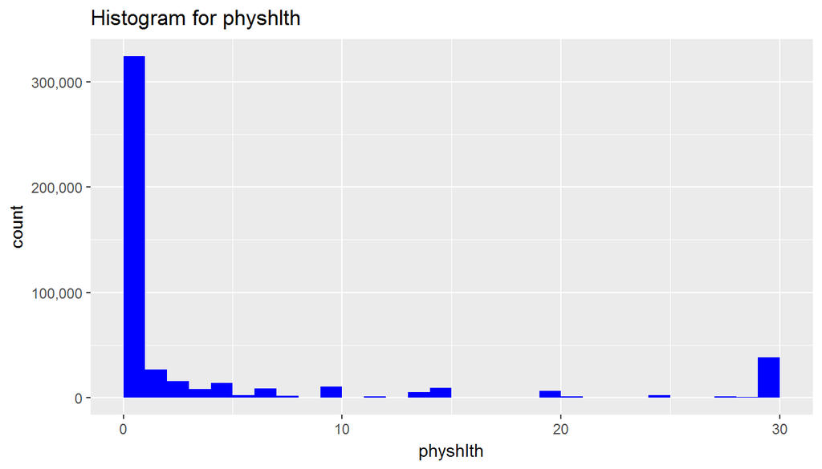

```r
brfss2013 %>%
  ggplot(aes(physhlth)) +
    geom_histogram(breaks=seq(0, 30, by = 1),
                   fill="blue") +
    scale_y_continuous(labels = comma) +
    labs(title="Histogram for physhlth")
```

Since the above mentioned variables are measured in days of the previous month, we can bin the variables so that it’ll be esier to deal with them. We will transform the NULLs in the “unknown” factor.

```r
brfss2013 <- brfss2013 %>%
                        mutate(poorhlth_factor =
                                 factor(ifelse(is.na(poorhlth), "unknown",
                                                 ifelse(poorhlth == 0, "no",
                                                        ifelse(poorhlth <= 10, "low",
                                                               ifelse(poorhlth <= 20, "medium", "high")))),
                                        levels=c("unknown", "no","low", "medium", "high")))


brfss2013 <- brfss2013 %>%
  mutate(menthlth_factor =
           factor(ifelse(is.na(menthlth), 'unknown',
                            ifelse(menthlth == 0, 'no',
                                   ifelse(menthlth <= 10, 'low',
                                          ifelse(menthlth <= 20, 'medium', 'high')))),
                     levels=c("unknown", "no","low", "medium", "high")))


brfss2013 <- brfss2013 %>%
  mutate(physhlth_factor =
           factor(ifelse(is.na(physhlth), 'unknown',
                            ifelse(physhlth == 0, 'no',
                                   ifelse(physhlth <= 10, 'low',
                                          ifelse(physhlth <= 20, 'medium', 'high')))),
                     levels=c("unknown", "no","low", "medium", "high")))
```

Let’s visualize the new binned variables.

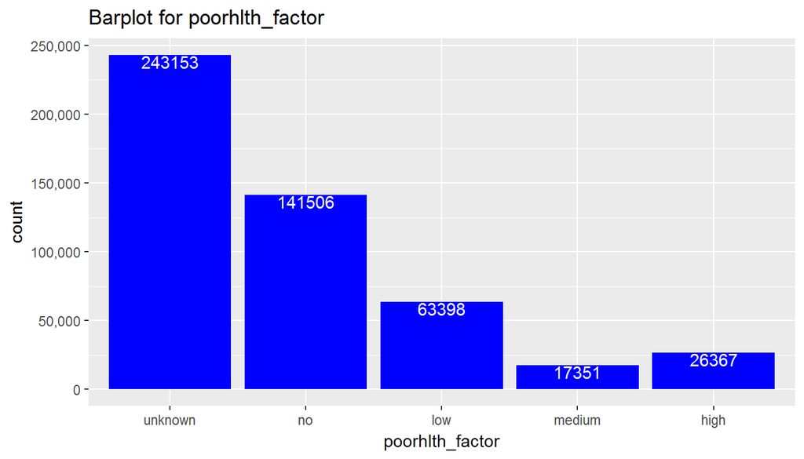

```r
brfss2013 %>%
  ggplot(aes(poorhlth_factor)) +
    geom_bar(fill="blue") +
    scale_y_continuous(labels = comma) +
    labs(title="Barplot for poorhlth_factor") +
    geom_text(stat = "count", aes(label=..count..), color="white", vjust = 1)
```

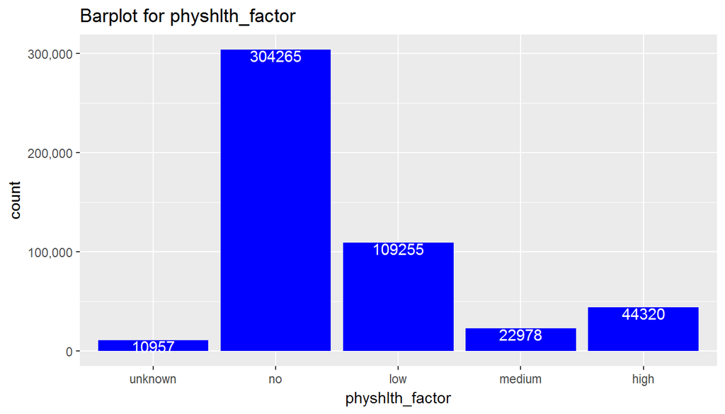

```r
brfss2013 %>%
  ggplot(aes(physhlth_factor)) +
    geom_bar(fill="blue") +
    scale_y_continuous(labels = comma) +
    labs(title="Barplot for physhlth_factor") +
    geom_text(stat = "count", aes(label=..count..), color="white", vjust = 1)
```

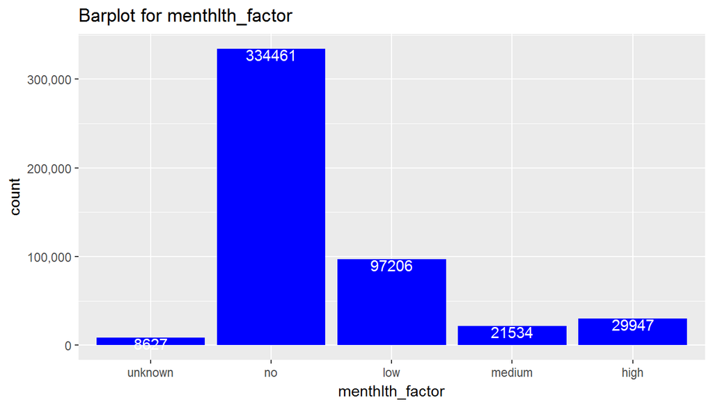

```r
brfss2013 %>%
  ggplot(aes(menthlth_factor)) +
    geom_bar(fill="blue") +
    scale_y_continuous(labels = comma) +
    labs(title="Barplot for menthlth_factor") +
    geom_text(stat = "count", aes(label=..count..), color="white", vjust = 1)
```

We first create two new variables to identify individuals who have a menatal and/or a physical desease (1 = unknown, 2 = no, 3 = low, 4 = medium, 5 = high)

```r
brfss2013 <- brfss2013 %>%
  mutate(has_ment = ifelse(as.numeric(menthlth_factor) > 2, 1,
                           ifelse(as.numeric(menthlth_factor) == 1, NA, 0)),
         has_phys = ifelse(as.numeric(physhlth_factor) > 2, 1,
                           ifelse(as.numeric(menthlth_factor) == 1, NA, 0)))

brfss2013 %>%
  group_by(has_ment) %>%
  summarise(count = n())
```

```
## # A tibble: 3 x 2
##   has_ment  count
##      <dbl>  <int>
## 1        0 334461
## 2        1 148687
## 3       NA   8627
```

```r
brfss2013 %>%
  group_by(has_phys) %>%
  summarise(count = n())
```

```
## # A tibble: 3 x 2
##   has_phys  count
##      <dbl>  <int>
## 1        0 309827
## 2        1 176553
## 3       NA   5395
```

It’s convenient to build a specific dataset to understand who declared he hasn’t poor health in the Main Survey - Section 2, but at the same time he declared to have one or both the desease. Let’s start by “melting” the *poorhlth_factor*, *has_ment* and *has_phys* variables.

```r
library(reshape2)

check_poorhlth_vs_mental_deseases <- brfss2013 %>%
                                      select(poorhlth_factor, has_ment, has_phys) %>%
                                      melt()

str(check_poorhlth_vs_mental_deseases)
```

```
## 'data.frame':    983550 obs. of  3 variables:
##  $ poorhlth_factor: Factor w/ 5 levels "unknown","no",..: 5 1 2 2 2 1 2 3 1 1 ...
##  $ variable       : Factor w/ 2 levels "has_ment","has_phys": 1 1 1 1 1 1 1 1 1 1 ...
##  $ value          : num  1 0 1 0 1 0 1 0 0 0 ...
```

```r
head(check_poorhlth_vs_mental_deseases, 10)
```

```
##    poorhlth_factor variable value
## 1             high has_ment     1
## 2          unknown has_ment     0
## 3               no has_ment     1
## 4               no has_ment     0
## 5               no has_ment     1
## 6          unknown has_ment     0
## 7               no has_ment     1
## 8              low has_ment     0
## 9          unknown has_ment     0
## 10         unknown has_ment     0
```

Now, filtering all the values equal to 1, we analyze only the individuals who explicitly declared to have any mental or physical deseases in the last 30 days. Grouping them, we obtain the required data set to be plotted.

```r
check_poorhlth_vs_mental_deseases_grouped <- check_poorhlth_vs_mental_deseases %>%
                                              filter(value == 1) %>%
                                              group_by(poorhlth_factor, variable) %>%
                                              summarise(count = n())

check_poorhlth_vs_mental_deseases_grouped
```

```
## # A tibble: 10 x 3
## # Groups:   poorhlth_factor [?]
##    poorhlth_factor variable count
##             <fctr>   <fctr> <int>
##  1         unknown has_ment  1978
##  2         unknown has_phys  3034
##  3              no has_ment 82997
##  4              no has_phys 81754
##  5             low has_ment 35580
##  6             low has_phys 52510
##  7          medium has_ment 11712
##  8          medium has_phys 15193
##  9            high has_ment 16420
## 10            high has_phys 24062
```

If we compare the result with what they have declared for the *poothlth_factor* variable, we can answer to the first question.

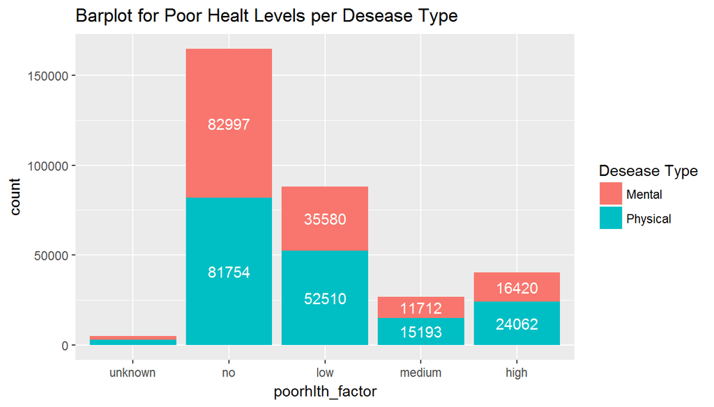

```r
check_poorhlth_vs_mental_deseases_grouped %>%
  ggplot(aes(x=poorhlth_factor, y=count, fill=variable)) +
    geom_bar(stat="identity", position="stack") +
    scale_fill_discrete(name="Desease Type",
                      breaks=c("has_ment", "has_phys"),
                      labels=c("Mental", "Physical")) +
    geom_text(aes(label=ifelse(count >= 6000, count,"")), color="white", position=position_stack(vjust=0.5)) +
    labs(title="Barplot for Poor Healt Levels per Desease Type")
```

Focusing our attention to the “no” value for the *poorhlth_factor*, it’s evident that mental and/or physical desease is often not considered as poor helath.

**Research quesion 2:**

*“Do individuals that declare to be nervous, hopeless, restless, etc. not recognize these deseases as mental deseases and so they declare to not have poor mental health?”*

We’ll use the Optional Module 17 - Mental Illness and Stigma to try to answer to this question. First of all we need to create more variables to get rid of the complexity.

```r
brfss2013 <- brfss2013 %>%
  mutate(is_nervous = ifelse(misnervs == "None", 0, 1),
         is_hopeless = ifelse(mishopls == "None", 0, 1),
         is_restless = ifelse(misrstls == "None", 0, 1),
         is_depressed = ifelse(misdeprd == "None", 0, 1),
         is_effort = ifelse(miseffrt == "None", 0, 1),
         is_worthless = ifelse(miswtles == "None", 0, 1)
  )

# Just check one new variable
brfss2013 %>%
  group_by(is_nervous) %>%
  summarise(count = n())
```

```
## # A tibble: 3 x 2
##   is_nervous  count
##        <dbl>  <int>
## 1          0  18008
## 2          1  18137
## 3         NA 455630
```

In order to analyze what kind of mental disease are part of the “no” and “unknown” values of *menthlth_factor*, we have to “pivot” (melt) our variables, to get only the ones having a value of 1 (explicitly declared by the individuals), and than group them.

```r
check_mental_unconscious <- brfss2013 %>%
                        filter(poorhlth_factor != 'no' & physhlth_factor == "no" &
                                 (menthlth_factor == "no" | menthlth_factor == 'unknown')) %>%
                        select(menthlth_factor, is_nervous, is_hopeless, is_restless,
                               is_depressed, is_effort, is_worthless) %>%
                        melt()

str(check_mental_unconscious)
```

```
## 'data.frame':    1426908 obs. of  3 variables:
##  $ menthlth_factor: Factor w/ 5 levels "unknown","no",..: 2 2 2 2 2 2 2 2 2 2 ...
##  $ variable       : Factor w/ 6 levels "is_nervous","is_hopeless",..: 1 1 1 1 1 1 1 1 1 1 ...
##  $ value          : num  1 NA NA NA NA NA NA NA NA NA ...
```

```r
check_mental_unconscious_grouped <- check_mental_unconscious %>%
                                      filter(value == 1) %>%
                                      group_by(menthlth_factor, variable) %>%
                                      summarise(count = n())

check_mental_unconscious_grouped
```

```
## # A tibble: 12 x 3
## # Groups:   menthlth_factor [?]
##    menthlth_factor     variable count
##             <fctr>       <fctr> <int>
##  1         unknown   is_nervous    31
##  2         unknown  is_hopeless    23
##  3         unknown  is_restless    29
##  4         unknown is_depressed    15
##  5         unknown    is_effort    26
##  6         unknown is_worthless    16
##  7              no   is_nervous  6197
##  8              no  is_hopeless  1169
##  9              no  is_restless  5059
## 10              no is_depressed   599
## 11              no    is_effort  2733
## 12              no is_worthless   597
```

Now it’s easy to visualize this data set.

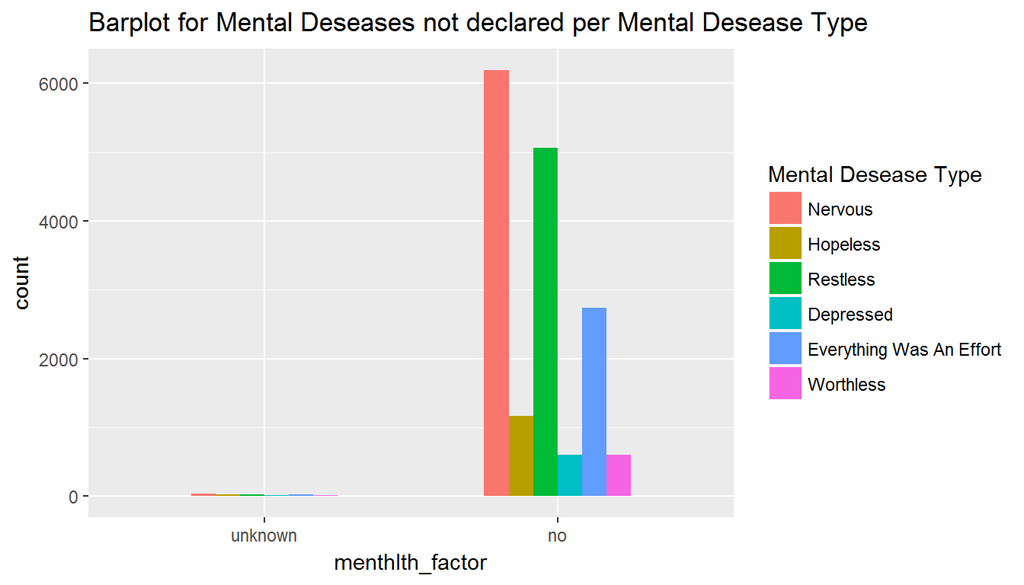

```r
check_mental_unconscious_grouped %>%
  ggplot(aes(x=menthlth_factor,y=count,fill=variable)) +
    geom_bar(width = 0.5, stat="identity",position="dodge") +
    scale_fill_discrete(name="Mental Desease Type",
                        breaks=c("is_nervous", "is_hopeless", "is_restless",
                                 "is_depressed", "is_effort", "is_worthless"),
                        labels=c("Nervous", "Hopeless", "Restless", "Depressed",
                                 "Everything Was An Effort", "Worthless")) +
    labs(title="Barplot for Mental Deseases not declared per Mental Desease Type")
```

So it’s evident that there is people declaring to have not had mental deseases even if they declare to be, for example, hopeless or even depressed.

**Research quesion 3:**

*May physical activity be correlated with mental healt? If yes, do more exercises a week doing healthier?*

Let’s study the Main Survey - Section 12 - Exercise (Physical Activity). The variable *exerany2* tell us if any physical activities or exercises such as running, calisthenics, golf, gardening, or walking for exercise have been done.

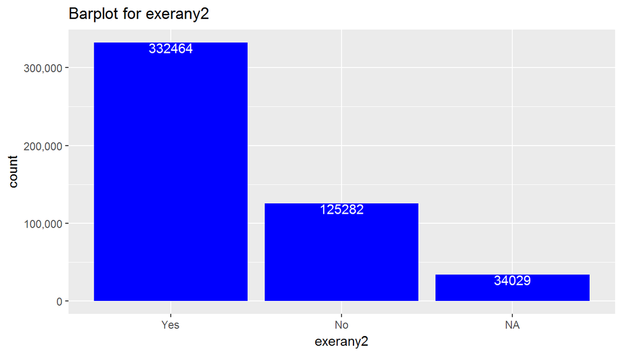

```r
brfss2013 %>%
  ggplot(aes(exerany2)) +
  geom_bar(fill="blue") +
  scale_y_continuous(labels = comma) +
  geom_text(stat = "count", aes(label=..count..), color="white", vjust = 1) +
  labs(title="Barplot for exerany2")
```

We can combine the *exerany2* with the *has_ment* one, defined in the previous section, grouping them and getting the number of instances.

```r
aerobic_vs_ment <- brfss2013 %>%
  mutate(has_ment = as.factor(ifelse(!is.na(has_ment), ifelse(has_ment == 1, "Yes", "No"), NA))) %>%
  group_by(exerany2, has_ment) %>%
  summarise(count = n())

aerobic_vs_ment
```

```
## # A tibble: 9 x 3
## # Groups:   exerany2 [?]
##   exerany2 has_ment  count
##     <fctr>   <fctr>  <int>
## 1      Yes       No 230607
## 2      Yes      Yes  97165
## 3      Yes       NA   4692
## 4       No       No  80195
## 5       No      Yes  42104
## 6       No       NA   2983
## 7       NA       No  23659
## 8       NA      Yes   9418
## 9       NA       NA    952
```

Now we can visualize this data in an easier way with a barplot.

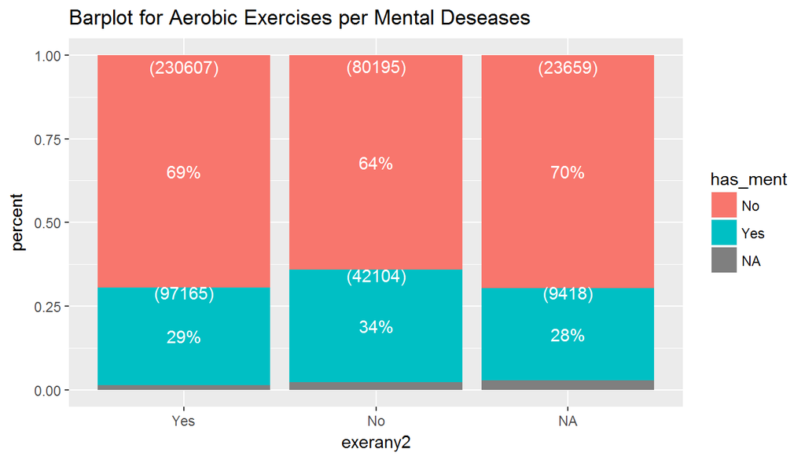

```r
aerobic_vs_ment %>%
  group_by(exerany2) %>%
  mutate(group_sum = sum(count)) %>%
  mutate(percent = count/group_sum) %>%
  ggplot(aes(x=exerany2, y=percent, fill=has_ment)) +
    geom_bar(stat="identity", position="stack") +
    geom_text(aes(label=ifelse(percent >= 0.07, paste0(sprintf("%.0f", percent*100),"%"),"")), color="white", position=position_stack(vjust=0.5)) +
    geom_text(aes(label=ifelse(count > 6000, paste0("(", count, ")"), "")), color="white", position=position_stack(vjust=0.95)) +
    labs(title="Barplot for Aerobic Exercises per Mental Deseases")
```

As you can see, 34% of individuals who don’t do any aerobic exericises has mental desease, whereas only 29% of individuals who do exercises has mental deseases. So we can suppose that exercises have a benefical effect to mental health.

Since it seems that exercises have a benefical effect, we can study how the frequencies of aerobic exercises in a week can impact to mental health.

Let’s analyze the frequencies of these aerobic activities through the *exeroft1* variable. In its definition we can find these values:

- [101 - 199] Times per week
- [201 - 299] Times per month

The first number denotes times per week (1) or month (2). The remaining digits indicate the count of times.

So let’s visualize its boxplot.

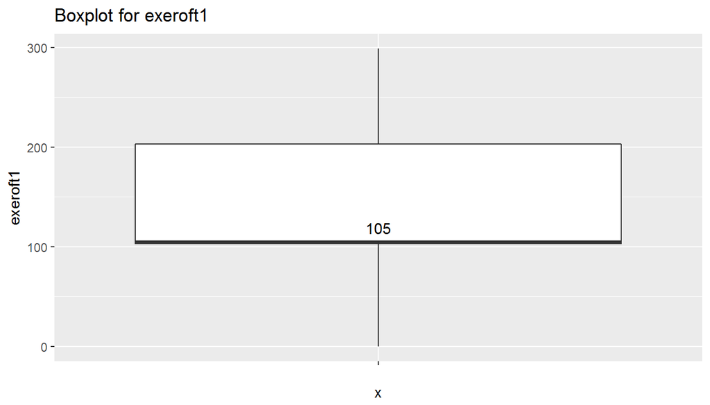

```r
fun_median <- function(x){ return(data.frame(y=median(x),label=median(x,na.rm=T))) }

brfss2013 %>%
  ggplot(aes(x="", y=exeroft1)) +
  geom_boxplot() +
  stat_summary(geom="text", vjust=-0.7,
               fun.data=fun_median) +
  labs(title="Boxplot for exeroft1")
```

From the above boxplot we can see that the majority of people who declared to do aerobic exercise prefer to measure it in days in a week (not in a month).

Analyzing the range between 100 and 200 (not included) we can understand how many times an individual do aerobic exercises in a week.

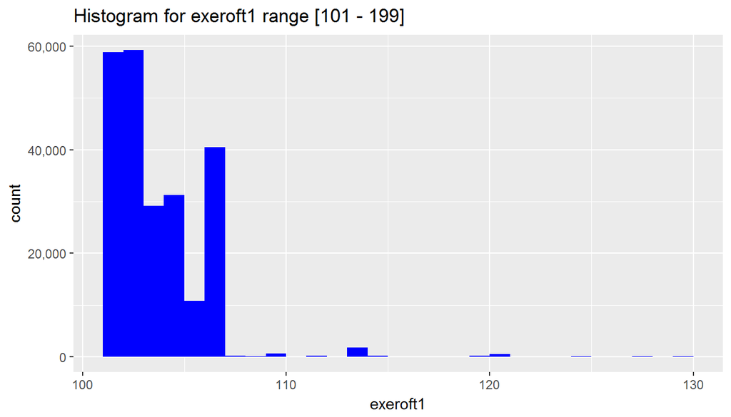

```r
# Histogram cut to 130, just to better see the main part of the distribution
brfss2013 %>%
  filter(exeroft1 > 100 & exeroft1 < 200) %>%
  ggplot(aes(exeroft1)) +
    geom_histogram(breaks=seq(101, 130, by = 1),
                   fill="blue") +
    scale_y_continuous(labels = comma) +
    labs(title="Histogram for exeroft1 range [101 - 199]")
```

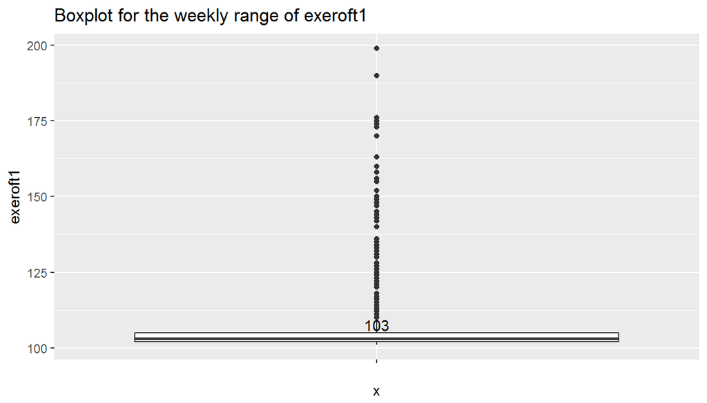

```r
brfss2013 %>%
  filter(exeroft1 > 100 & exeroft1 < 200) %>%
  ggplot(aes(x="", y=exeroft1)) +
    geom_boxplot() +
    stat_summary(geom="text", vjust=-0.7,
                 fun.data=fun_median) +
    labs(title="Boxplot for the weekly range of exeroft1")
```

The median is 103, so 3 times a week.

Analyzing the range between 200 and 300 (not included) we can understand how many times an individual do aerobic exercises in a month.

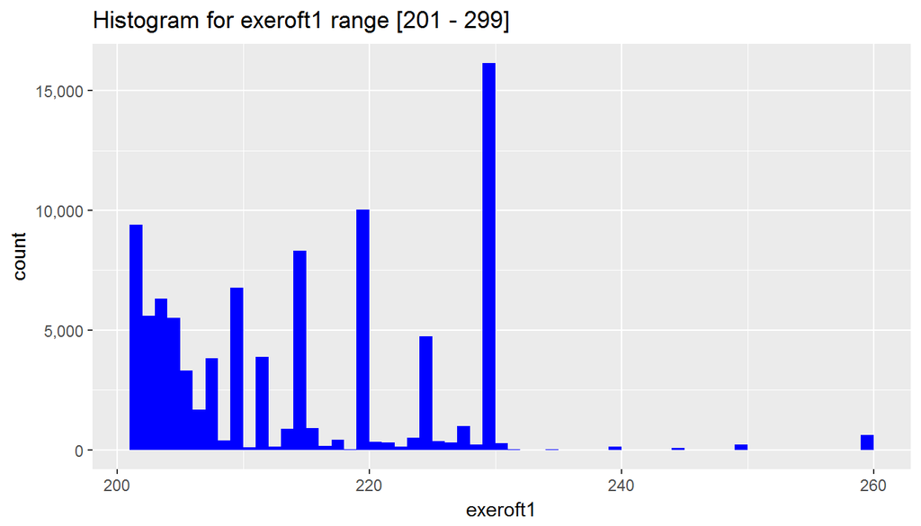

```r
# Histogram cut to 260, just to better see the main part of the distribution
brfss2013 %>%
  filter(exeroft1 > 200 & exeroft1 < 300) %>%
  ggplot(aes(exeroft1)) +
    geom_histogram(breaks=seq(201, 260, by = 1),
                   fill="blue") +
    scale_y_continuous(labels = comma) +
    labs(title="Histogram for exeroft1 range [201 - 299]")
```

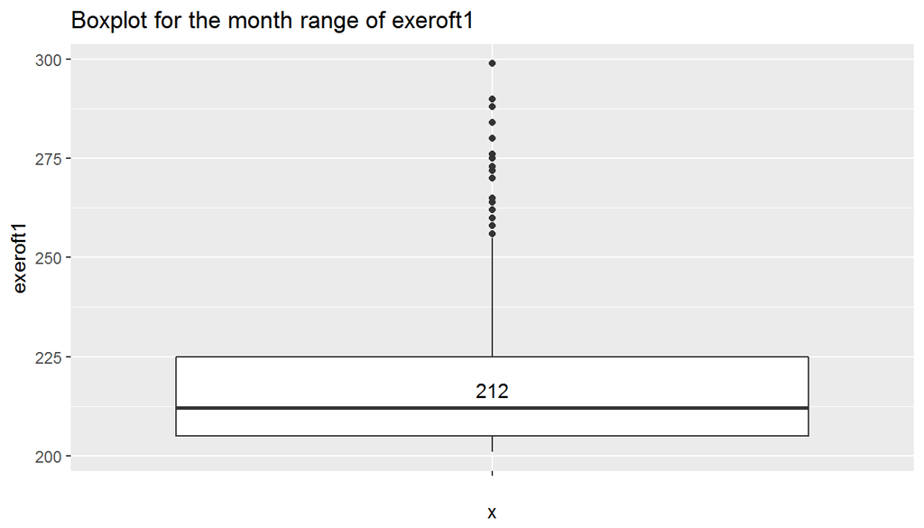

```r
brfss2013 %>%
  filter(exeroft1 > 200 & exeroft1 < 300) %>%
  ggplot(aes(x="", y=exeroft1)) +
  geom_boxplot() +
  stat_summary(geom="text", vjust=-0.7,
               fun.data=fun_median) +
  labs(title="Boxplot for the month range of exeroft1")
```

The median is 212, so 12 times a month, that is 3 times a week on average.

So we can create a new variable (*exeroft1_factor*) that bins the *exeroft1* one in this way: 1 times a week is low, 2 or 3 times a week is medium, more than 3 times a week is high.

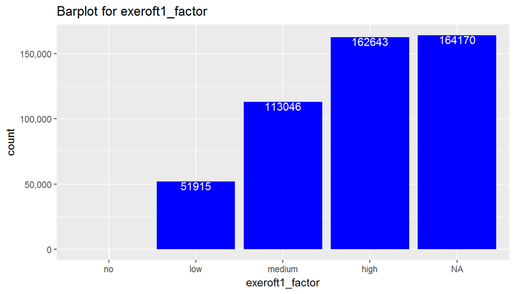

```r
brfss2013 <- brfss2013 %>%
  mutate(exeroft1_factor = factor(ifelse(is.na(exeroft1), NA,
                                            ifelse(exeroft1 == 0, "no",
                                                   ifelse(exeroft1 > 100 & exeroft1 < 200,
                                                          ifelse(exeroft1 - 100 == 1, "low",
                                                                 ifelse(exeroft1 - 100 <= 3, "medium", "high")
                                                          ),
                                                          ifelse(exeroft1 > 200 & exeroft1 < 300,
                                                                 ifelse( (exeroft1 - 200) / 4 < 2, "low",
                                                                         ifelse( (exeroft1 - 200) / 4 <= 3, "medium", "high")
                                                                 ),
                                                                 NA
                                                          )
                                                   )
                                            )
                                      ),
                                  levels=c("no","low", "medium", "high")))

brfss2013 %>%
  ggplot(aes(exeroft1_factor)) +
  geom_bar(fill="blue") +
  scale_y_continuous(labels = comma) +
  geom_text(stat = "count", aes(label=..count..), color="white", vjust = 1) +
  labs(title="Barplot for exeroft1_factor")
```

It makes sense to visualize this variable related to the *exerany2* one, since *exeroft1* values should be related only to the “Yes” value of *exerany2*. First we need to group and summarize our values.

```r
aerobic <- brfss2013 %>%
  group_by(exerany2, exeroft1_factor) %>%
  summarise(count = n())

aerobic
```

```
## # A tibble: 7 x 3
## # Groups:   exerany2 [?]
##   exerany2 exeroft1_factor  count
##     <fctr>          <fctr>  <int>
## 1      Yes             low  51915
## 2      Yes          medium 113046
## 3      Yes            high 162643
## 4      Yes              NA   4860
## 5       No              NA 125282
## 6       NA              no      1
## 7       NA              NA  34028
```

Then we can plot this data set with a barplot.

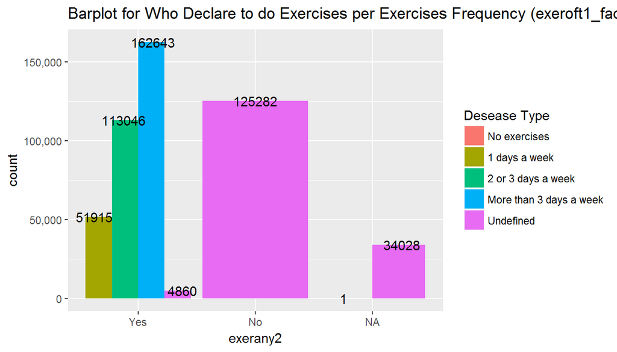

```r
aerobic %>%
  mutate(exeroft1_factor = factor(exeroft1_factor, levels = levels(addNA(exeroft1_factor)),
                                  labels = c(levels(exeroft1_factor), "undefined"), exclude = NULL)) %>%
  ggplot(aes(x=exerany2, y=count, fill=exeroft1_factor)) +
  geom_bar(stat="identity", position="dodge") +
  scale_y_continuous(labels = comma) +
  scale_fill_discrete(name="Desease Type",
                      breaks=c("no", "low", "medium", "high", "undefined"),
                      labels=c("No exercises", "1 days a week", "2 or 3 days a week",
                               "More than 3 days a week", "Undefined")) +
  geom_text(aes(label=count), color="black", position = position_dodge(1)) +
  labs(title="Barplot for Who Declare to do Exercises per Exercises Frequency (exeroft1_factor)")
```

Finally we can combine the *exeroft1_factor* variable with the *has_ment* one, grouping them and getting the number of instances.

```r
aerobic_freq_vs_ment <- brfss2013 %>%
  mutate(has_ment = as.factor(ifelse(!is.na(has_ment), ifelse(has_ment == 1, "Yes", "No"), NA))) %>%
  filter(exeroft1_factor != "no") %>% # Get rid of the "no" value, since it is a mistake
  group_by(exeroft1_factor, has_ment) %>%
  summarise(count = n())

aerobic_freq_vs_ment
```

```
## # A tibble: 9 x 3
## # Groups:   exeroft1_factor [?]
##   exeroft1_factor has_ment  count
##            <fctr>   <fctr>  <int>
## 1             low       No  33861
## 2             low      Yes  17255
## 3             low       NA    799
## 4          medium       No  77429
## 5          medium      Yes  34292
## 6          medium       NA   1325
## 7            high       No 115983
## 8            high      Yes  44455
## 9            high       NA   2205
```

For a better understanding of the data, we can plot the data set in a barplot.

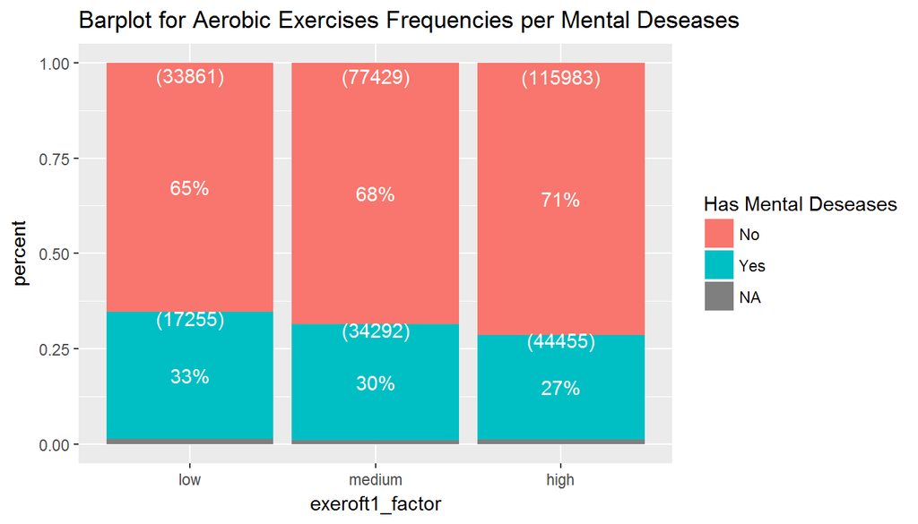

```r
aerobic_freq_vs_ment %>%
  group_by(exeroft1_factor) %>%
  mutate(group_sum = sum(count)) %>%
  mutate(percent = count/group_sum) %>%
  ggplot(aes(x=exeroft1_factor, y=percent, fill=has_ment)) +
  geom_bar(stat="identity", position="stack") +
  scale_fill_discrete(name="Has Mental Deseases") +
  geom_text(aes(label=ifelse(percent >= 0.07, paste0(sprintf("%.0f", percent*100),"%"),"")), color="white", position=position_stack(vjust=0.5)) +
  geom_text(aes(label=ifelse(count > 6000, paste0("(", count, ")"), "")), color="white", position=position_stack(vjust=0.95)) +
  labs(title="Barplot for Aerobic Exercises Frequencies per Mental Deseases")
```

It’s evident that the percentage of people with mental deseases is decreasing with the increasing of the frequency of the exercises in a week.

So this study can be a clue of a possible causal relation between exercises and mental health. Only a dedicated randomized experiment can demonstrate the causal connection between them.